# Nora Elhaissouni’s Statistical Computing: Project 3

2023-10-21

# Part 1: Explore album sales

## Part 1A:

Use lubridate to create a column called released that is a Date class. However, to be able to do this, you first need to use stringr to search for pattern that matches things like this “(US)[51]” in a string like this “September 1, 2006 (US)[51]” and removes them. (Note: to get full credit, you must create the regular expression). Use forcats to create a factor called country (Note: you may need to collapse some factor levels). Transform the sales into a unit that is album sales in millions of dollars. Keep only album sales from the UK, the US or the World. Auto print your final wrangled tibble data frame.

```r
sales <- sales %>%
  mutate(released = str_remove(released, "\\s*\\(\\w+\\)\\[\\d+\\]"), released) %>%
  mutate(released = as.Date(released, format = "%B %d, %Y"))%>%
  mutate(album_sales_permil = sales/1000000) %>%
  mutate(country = ifelse(country == "World", "WW", country)) %>%
  mutate(country = ifelse(country == "FRA", "FR", country)) %>%
  filter(country %in% c("UK", "US", "WW"))

country_levels<- c("US", "WW", "AUS", "UK", "JPN", "CAN", "FR") # World is changed to WW and FRA to FR
country<- factor(sales$country, levels = country_levels)

sales
```

```
## # A tibble: 36 × 9
##    artist       title        country   sales released   re_release label formats
##    <chr>        <chr>        <chr>     <dbl> <date>     <chr>      <chr> <chr>
##  1 Taylor Swift Taylor Swift US       5.72e6 2006-10-24 March 18,… Big … CD, CD…
##  2 Taylor Swift Fearless     WW       1.20e7 2008-11-11 October 2… Big … CD, CD…
##  3 Taylor Swift Fearless     US       7.18e6 2008-11-11 October 2… Big … CD, CD…
##  4 Taylor Swift Fearless     UK       6.09e5 2008-11-11 October 2… Big … CD, CD…
##  5 Taylor Swift Speak Now    WW       5   e6 2010-10-25 <NA>       Big … CD, CD…
##  6 Taylor Swift Speak Now    US       4.69e6 2010-10-25 <NA>       Big … CD, CD…
##  7 Taylor Swift Speak Now    UK       1.69e5 2010-10-25 <NA>       Big … CD, CD…
##  8 Taylor Swift Red          WW       6   e6 2012-10-22 <NA>       Big … CD, CD…
##  9 Taylor Swift Red          US       4.47e6 2012-10-22 <NA>       Big … CD, CD…
## 10 Taylor Swift Red          UK       6.93e5 2012-10-22 <NA>       Big … CD, CD…
## # ℹ 26 more rows
## # ℹ 1 more variable: album_sales_permil <dbl>
```

## Part 1B

Keep only album sales from the US. Create a new column called years_since_release corresponding to the number of years since the release of each album from Beyoncé and Taylor Swift. This should be a whole number and you should round down to “14” if you get a non-whole number like “14.12” years. (Hint: you may find the interval() function from lubridate helpful here, but this not the only way to do this.) Calculate the most recent, oldest, and the median years since albums were released for both Beyoncé and Taylor Swift.

```r
current_year = 2023
sales<- sales %>% mutate(years_since_release = floor(current_year - year(released)))


t_swift_info<- sales %>% filter(artist == "Taylor Swift", country == "US") %>% summarise(Tswift_min_years = min(years_since_release), Tswift_max_years = max(years_since_release), Tswift_med_years = median(years_since_release))
beyonce_info<- sales %>% filter(artist == "Beyoncé", country == "US") %>% summarise(beyonce_min_years = min(years_since_release), beyone_max_years = max(years_since_release), beyonce_med_years = median(years_since_release))

tibble(t_swift_info)
```

```
## # A tibble: 1 × 3
##   Tswift_min_years Tswift_max_years Tswift_med_years
##              <dbl>            <dbl>            <dbl>
## 1                4               17               11
```

```r
tibble(beyonce_info)
```

```
## # A tibble: 1 × 3
##   beyonce_min_years beyone_max_years beyonce_med_years
##               <dbl>            <dbl>             <dbl>
## 1                 7               20              13.5
```

## Part 1C

Using the wrangled data from Part 1A:

Calculate the total album sales for each artist and for each country (only sales from the UK, US, and World). Note: assume that the World sales do not include the UK and US ones. Using the total album sales, create a percent stacked barchart using ggplot2 of the percentage of sales of studio albums (in millions) along the y-axis for the two artists along the x-axis colored by the country.

```r
total_sales <- sales %>%
  filter(artist %in% c("Taylor Swift", "Beyoncé") & country %in% c("UK", "US", "WW")) %>%
  group_by(artist, country) %>%
  summarize(total_album_sales = sum(album_sales_permil))
```

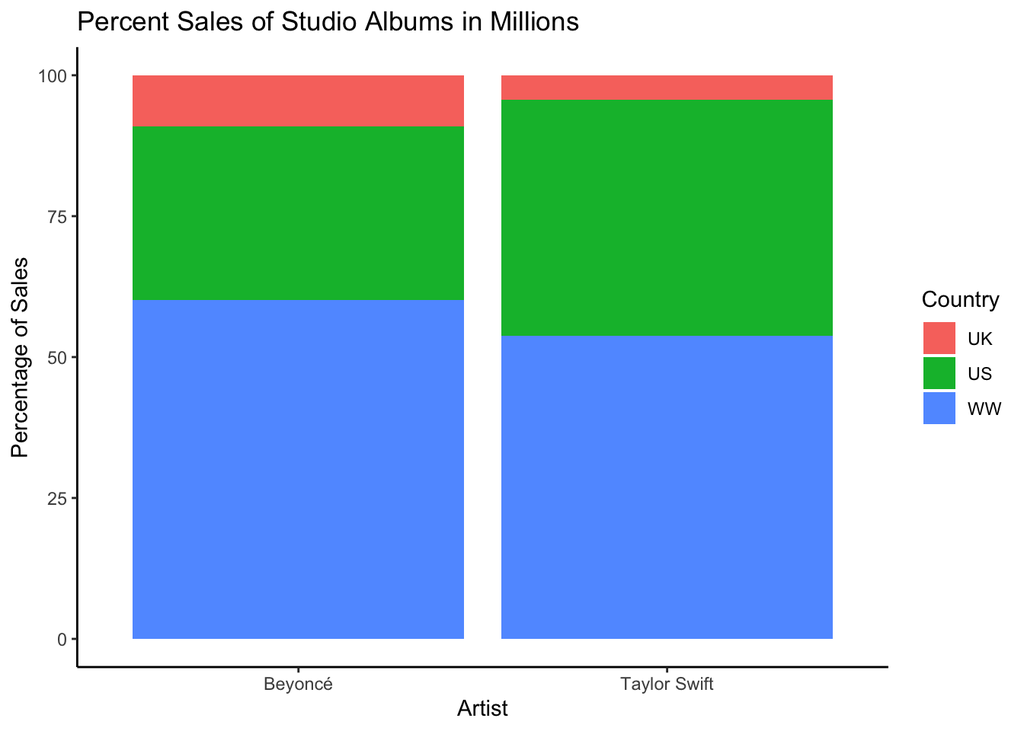

```r
total_sales <- total_sales %>%
  group_by(artist) %>%
  mutate(percentage = total_album_sales / sum(total_album_sales) * 100)
ggplot(total_sales, aes(x = artist, y = percentage, fill = country)) +
  geom_bar(stat = "identity") +
  labs(x = "Artist", y = "Percentage of Sales", fill = "Country", title = "Percent Sales of Studio Albums in Millions") +
  theme_classic()
```

## Part 1D

Using the wrangled data from Part 1A, use ggplot2 to create a bar plot for the sales of studio albums (in millions) along the x-axis for each of the album titles along the y-axis.

Note:

You only need to consider the global World sales (you can ignore US and UK sales for this part). Hint: how would you abbreviate WorldWide? The title of the album must be clearly readable along the y-axis. Each bar should be colored by which artist made that album. The bars should be ordered from albums with the most sales (top) to the least sales (bottom) (Note: you must use functions from forcats for this step).

[figure not shown]

```r
# Back in part 1A I changed World to WW
sales %>% group_by(title) %>% ggplot(aes(x = album_sales_permil, y = fct_reorder(title, album_sales_permil, .fun = sum), fill = artist)) +
  geom_bar(stat = "identity") +
  labs(x = "Artist", y = "Album", fill = "Artist", title = "Global World Sales of Studio Albums in Millions") +
  theme_classic()
```

## Part 1E

Using the wrangled data from Part 1A, use ggplot2 to create a scatter plot of sales of studio albums (in millions) along the y-axis by the released date for each album along the x-axis. Note: The points should be colored by the artist. There should be three scatter plots (one for UK, US and world sales) faceted by rows.

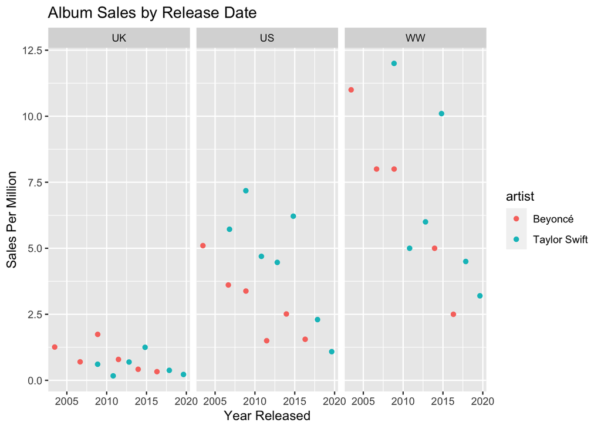

```r
sales %>%
  ggplot(aes(x = released, y = album_sales_permil, color = artist)) +
  geom_point() +
  facet_wrap(~ country) +
 labs(x = "Year Released", y = "Sales Per Million", title = "Album Sales by Release Date")
```

# Part 2: Exploring Sentiment of Lyrics

## Part 2A

Using ts_lyrics, create a new column called line with one line containing the character string for each line of Taylor Swift’s songs.

How many lines in Taylor Swift’s lyrics contain the word “hello”? For full credit, show all the rows in ts_lyrics that have “hello” in the line column and report how many rows there are in total. How many lines in Taylor Swift’s lyrics contain the word “goodbye”? For full credit, show all the rows in ts_lyrics that have “goodbye” in the line column and report how many rows there are in total.

```r
ts_lyrics<- ts_lyrics %>%
  unnest_tokens(
    output = line,
    input = Lyrics,
    token = "lines"
  )
ts_lyrics_hello<- ts_lyrics %>% filter(grepl("hello", line, ignore.case = TRUE))
print(paste("Row Number: ", nrow(ts_lyrics_hello))) # 6 rows total
```

```
## [1] "Row Number:  6"
```

```r
ts_lyrics_hello #printing the rows out
```

```
## # A tibble: 6 × 4
##   Artist       Album    Title                  line
##   <chr>        <chr>    <chr>                  <chr>
## 1 Taylor Swift Fearless Love Story             "and say, \"hello\""
## 2 Taylor Swift Red      I Almost Do            "that i can't say \"hello\" to y…
## 3 Taylor Swift Red      Everything Has Changed "'cause all i know is we said he…
## 4 Taylor Swift Red      Everything Has Changed "'cause all i know is we said he…
## 5 Taylor Swift Red      Everything Has Changed "all i know is we said hello"
## 6 Taylor Swift Red      Everything Has Changed "all i know is we said hello"
```

```r
ts_lyrics_goodbye<- ts_lyrics %>% filter(grepl("goodbye", line, ignore.case = TRUE))
print(paste("Row Number: ", nrow(ts_lyrics_goodbye))) # 12 rows total
```

```
## [1] "Row Number:  12"
```

```r
ts_lyrics_goodbye #printing the rows out
```

```
## # A tibble: 12 × 4
##    Artist       Album        Title                      line
##    <chr>        <chr>        <chr>                      <chr>
##  1 Taylor Swift Taylor Swift Tied Together With A Smile "goodbye, baby"
##  2 Taylor Swift Speak Now    Mine                       "braced myself for the …
##  3 Taylor Swift Speak Now    Back to December           "you gave me all your l…
##  4 Taylor Swift Speak Now    Long Live                  "and force us into a go…
##  5 Taylor Swift Red          I Almost Do                "and risk another goodb…
##  6 Taylor Swift Red          Come Back Be Here          "stumbled through the l…
##  7 Taylor Swift 1989         All You Had to Do Was Stay "but people like me are…
##  8 Taylor Swift reputation   Getaway Car                "said goodbye in "
##  9 Taylor Swift reputation   Getaway Car                "said goodbye in "
## 10 Taylor Swift Lover        Death By A Thousand Cuts   "saying goodbye is deat…
## 11 Taylor Swift Lover        Death By A Thousand Cuts   "'cause saying goodbye …
## 12 Taylor Swift Lover        Daylight                   "i'll tell you truth, b…
```

## Part 2B

```r
b_lyrics<- b_lyrics %>%
  unnest_tokens(
    output = line,
    input = line,
    token = "lines"
  )
b_lyrics_hello<- b_lyrics %>% filter(grepl("hello", line, ignore.case = TRUE))
print(paste("Row Number: ", nrow(b_lyrics_hello))) # 91 rows total
```

```
## [1] "Row Number:  91"
```

```r
b_lyrics_hello #printing the rows out
```

```
## # A tibble: 91 × 6
##    line                        song_id song_name artist_id artist_name song_line
##    <chr>                         <dbl> <chr>         <dbl> <chr>           <dbl>
##  1 hello world, well i just b… 2220711 "Dreamgi…       498 Beyoncé             5
##  2 hello stevie, how you feel… 1981227 "Fingert…       498 Beyoncé             6
##  3 fellow great americans, he… 2715227 "FREEDOM…       498 Beyoncé            52
##  4 you had me at hello (hello)   80249 "Hello"         498 Beyoncé            15
##  5 hello (hello)                 80249 "Hello"         498 Beyoncé            16
##  6 hello (hello)                 80249 "Hello"         498 Beyoncé            17
##  7 you had me at hello (hello)   80249 "Hello"         498 Beyoncé            18
##  8 hello (hello)                 80249 "Hello"         498 Beyoncé            19
##  9 hello (hello)                 80249 "Hello"         498 Beyoncé            20
## 10 'cause you had me at hello…   80249 "Hello"         498 Beyoncé            24
## # ℹ 81 more rows
```

```r
b_lyrics_goodbye<- b_lyrics %>% filter(grepl("goodbye", line, ignore.case = TRUE))
print(paste("Row Number: ", nrow(b_lyrics_goodbye))) # 12 rows total
```

```
## [1] "Row Number:  12"
```

```r
b_lyrics_goodbye #printing the rows out
```

```
## # A tibble: 12 × 6
##    line                        song_id song_name artist_id artist_name song_line
##    <chr>                         <dbl> <chr>         <dbl> <chr>           <dbl>
##  1 we only said goodbye with …  139043 Back to …       498 Beyoncé            12
##  2 we only said goodbye with …  139043 Back to …       498 Beyoncé            21
##  3 we only said goodbye with …  139043 Back to …       498 Beyoncé            24
##  4 thank god, i found the goo…   51492 Best Thi…       498 Beyoncé            38
##  5 thank god, i found the goo… 1946060 Best Thi…       498 Beyoncé            42
##  6 thank god, i found the goo… 4241137 Best Thi…       498 Beyoncé            38
##  7 it's so hard to say goodbye  435491 Gift fro…       498 Beyoncé            23
##  8 i never want to say goodbye  435491 Gift fro…       498 Beyoncé            24
##  9 i never, ever want to say …  435491 Gift fro…       498 Beyoncé            25
## 10 we've got to say goodbye    1844620 Hard To …       498 Beyoncé            29
## 11 don't have to say goodbye   1224115 Slow Love       498 Beyoncé            42
## 12 somewhere between hi and g…  141848 Yes             498 Beyoncé            27
```

## Part 2C

Using the b_lyrics dataset,

Tokenize each lyrical line by words. Remove the “stopwords”. Calculate the total number for each word in the lyrics. Using the “bing” sentiment lexicon, add a column to the summarized data frame adding the “bing” sentiment lexicon. Sort the rows from most frequent to least frequent words. Only keep the top 25 most frequent words. Auto print the wrangled tibble data frame. Use ggplot2 to create a bar plot with the top words on the y-axis and the frequency of each word on the x-axis. Color each bar by the sentiment of each word from the “bing” sentiment lexicon. Bars should be ordered from most frequent on the top to least frequent on the bottom of the plot. Create a word cloud of the top 25 most frequent words.

```r
b_lyrics_tokens<- b_lyrics %>%
  unnest_tokens(
    output = word,
    input = line,
    token = "words"
  ) %>% anti_join(stop_words) %>%
  inner_join(get_sentiments("bing"), by = "word")
#Calculate the most freq words
b_lyrics_count<- b_lyrics_tokens %>% count(word, sort = TRUE) %>% top_n(25)
b_lyrics_count #output the 25 top words and the freq
```

```
## # A tibble: 25 × 2
##    word          n
##    <chr>     <int>
##  1 love       1362
##  2 crazy       308
##  3 top         241
##  4 bad         132
##  5 beautiful   131
##  6 whoa        121
##  7 damn        106
##  8 hurt         90
##  9 hard         87
## 10 ready        85
## # ℹ 15 more rows
```

```r
b_lyrics_tokens<- b_lyrics_tokens %>%
  inner_join(b_lyrics_count, by = "word") %>% mutate(count = n)
b_lyrics_tokens<- unique(b_lyrics_tokens)
b_lyrics_tokens #autoprinting here
```

```
## # A tibble: 3,066 × 9
##    song_id song_name artist_id artist_name song_line word  sentiment     n count
##      <dbl> <chr>         <dbl> <chr>           <dbl> <chr> <chr>     <int> <int>
##  1   50396 1+1             498 Beyoncé             2 damn  negative    106   106
##  2   50396 1+1             498 Beyoncé             7 love  positive   1362  1362
##  3   50396 1+1             498 Beyoncé             9 love  positive   1362  1362
##  4   50396 1+1             498 Beyoncé            11 love  positive   1362  1362
##  5   50396 1+1             498 Beyoncé            12 love  positive   1362  1362
##  6   50396 1+1             498 Beyoncé            13 love  positive   1362  1362
##  7   50396 1+1             498 Beyoncé            15 love  positive   1362  1362
##  8   50396 1+1             498 Beyoncé            24 love  positive   1362  1362
##  9   50396 1+1             498 Beyoncé            26 love  positive   1362  1362
## 10   50396 1+1             498 Beyoncé            28 love  positive   1362  1362
## # ℹ 3,056 more rows
```

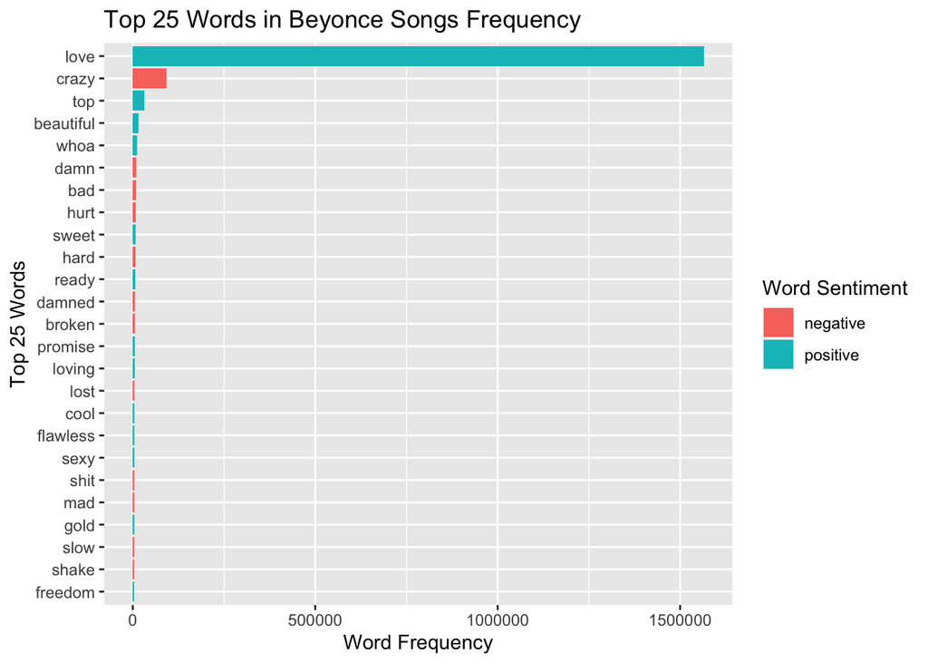

```r
b_lyrics_tokens %>% group_by(word) %>% ggplot(aes(x = count, y = fct_reorder(.f = word, .x = count, .fun = sum), fill = sentiment))+
  geom_bar(stat = "identity")+
  labs(x = "Word Frequency", y = "Top 25 Words", title = "Top 25 Words in Beyonce Songs Frequency", fill = "Word Sentiment")
```

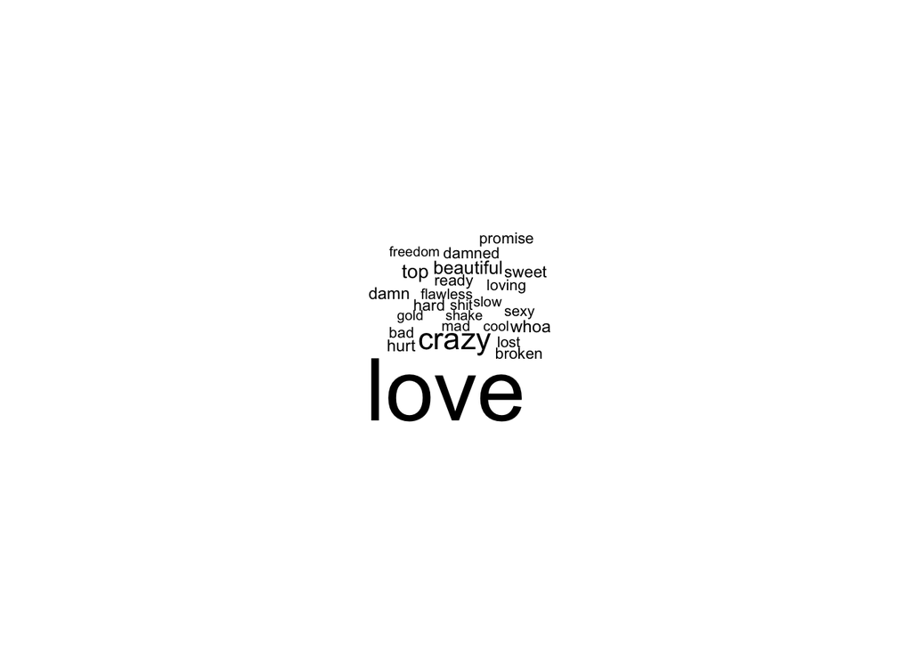

```r
b_lyrics_tokens %>% count(word) %>% with(wordcloud(word, n, max.words = 25))
```

## Part 2D

```r
ts_lyrics_tokens<- ts_lyrics %>%
  unnest_tokens(
    output = word,
    input = line,
    token = "words"
  ) %>% anti_join(stop_words) %>%
  inner_join(get_sentiments("bing"), by = "word")
#Calculate the most freq words
ts_lyrics_count<- ts_lyrics_tokens %>% count(word, sort = TRUE) %>% top_n(25)
ts_lyrics_count
```

```
## # A tibble: 25 × 2
##    word          n
##    <chr>     <int>
##  1 love        248
##  2 bad          80
##  3 shake        73
##  4 break        59
##  5 mad          48
##  6 beautiful    46
##  7 smile        45
##  8 hate         44
##  9 fall         43
## 10 whoa         36
## # ℹ 15 more rows
```

```r
ts_lyrics_tokens<- ts_lyrics_tokens %>%
  inner_join(ts_lyrics_count, by = "word") %>% mutate(count = n)
ts_lyrics_tokens<- unique(ts_lyrics_tokens)
ts_lyrics_tokens #autoprinting here
```

```
## # A tibble: 371 × 7
##    Artist       Album        Title                  word   sentiment     n count
##    <chr>        <chr>        <chr>                  <chr>  <chr>     <int> <int>
##  1 Taylor Swift Taylor Swift Tim McGraw             hard   negative     27    27
##  2 Taylor Swift Taylor Swift Tim McGraw             nice   positive     32    32
##  3 Taylor Swift Taylor Swift Picture to Burn        love   positive    248   248
##  4 Taylor Swift Taylor Swift Picture to Burn        crazy  negative     23    23
##  5 Taylor Swift Taylor Swift Picture to Burn        hate   negative     44    44
##  6 Taylor Swift Taylor Swift Picture to Burn        bad    negative     80    80
##  7 Taylor Swift Taylor Swift Teardrops on my Guitar fake   negative     20    20
##  8 Taylor Swift Taylor Swift Teardrops on my Guitar smile  positive     45    45
##  9 Taylor Swift Taylor Swift Teardrops on my Guitar beaut… positive     46    46
## 10 Taylor Swift Taylor Swift Teardrops on my Guitar love   positive    248   248
## # ℹ 361 more rows
```

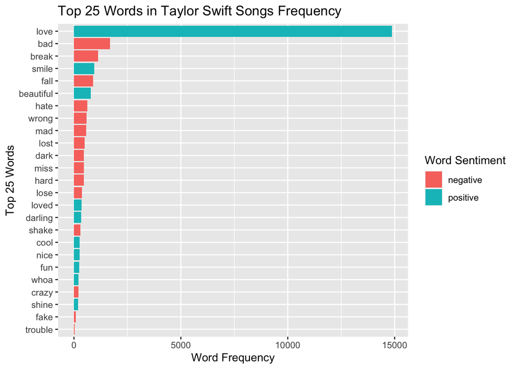

```r
ts_lyrics_tokens %>% group_by(word) %>% ggplot(aes(x = count, y = fct_reorder(.f = word, .x = count, .fun = sum), fill = sentiment))+
  geom_bar(stat = "identity")+
  labs(x = "Word Frequency", y = "Top 25 Words", title = "Top 25 Words in Taylor Swift Songs Frequency", fill = "Word Sentiment")
```

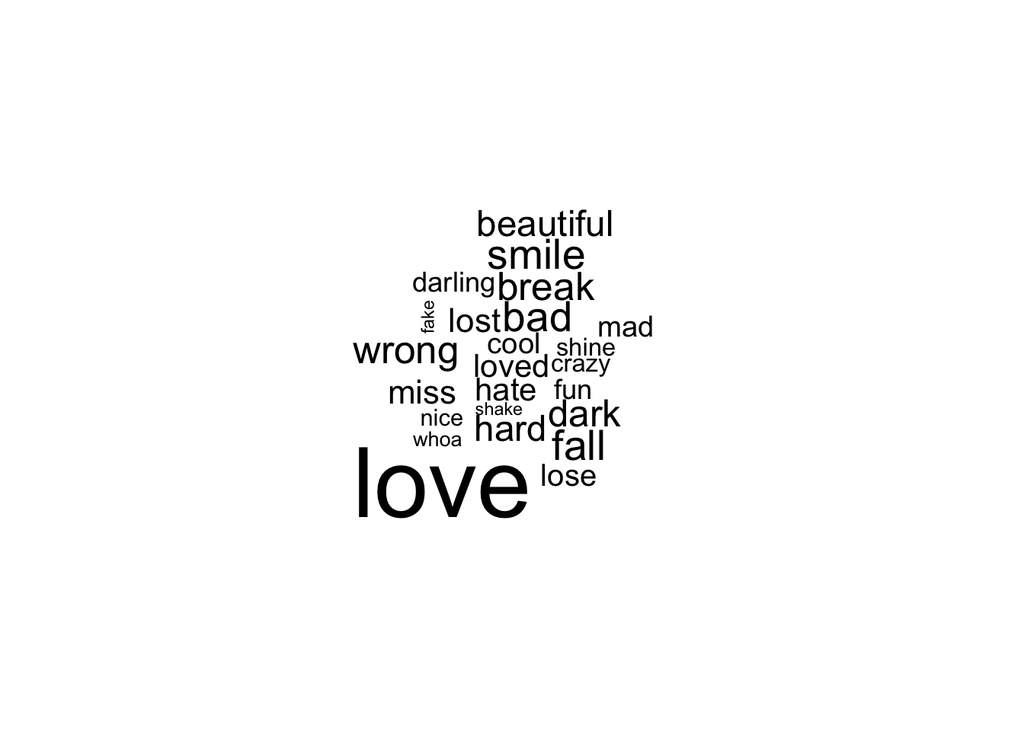

```r
ts_lyrics_tokens %>% count(word) %>% with(wordcloud(word, n, max.words = 25))
```

## Part 2E:

Using the ts_lyrics dataset,

Tokenize each lyrical line by words. Remove the “stopwords”. Calculate the total number for each word in the lyrics for each Album. Using the “afinn” sentiment lexicon, add a column to the summarized data frame adding the “afinn” sentiment lexicon. Calculate the average sentiment score for each Album. Auto print the wrangled tibble data frame. Join the wrangled data frame from Part 1A (album sales in millions) filtered down to US sales with the wrangled data frame from #6 above (average sentiment score for each album). Using ggplot2, create a scatter plot of the average sentiment score for each album (y-axis) and the album release data along the x-axis. Make the size of each point the album sales in millions. Add a horizontal line at y-intercept=0. Write 2-3 sentences interpreting the plot answering the question “How has the sentiment of Taylor Swift’s albums have changed over time?”. Add a title, subtitle, and useful axis labels.

```r
sentiments_afinn <- get_sentiments("afinn")
ts_afinn_album<- ts_lyrics %>%
  unnest_tokens(
    output = word,
    input = line,
    token = "words"
  ) %>% anti_join(stop_words) %>% group_by(Album) %>% count(word, sort = TRUE) %>%
  inner_join(get_sentiments("afinn")) %>% summarise(Album = Album, avg_sent = mean(value))
unique(ts_afinn_album) #autoprinting
```

```
## # A tibble: 8 × 2
## # Groups:   Album [8]
##   Album        avg_sent
##   <chr>           <dbl>
## 1 1989         -0.822
## 2 Fearless      0.0192
## 3 Lover        -0.429
## 4 Red          -0.00870
## 5 Speak Now    -0.365
## 6 Taylor Swift  0.137
## 7 folklore     -0.613
## 8 reputation   -0.495
```

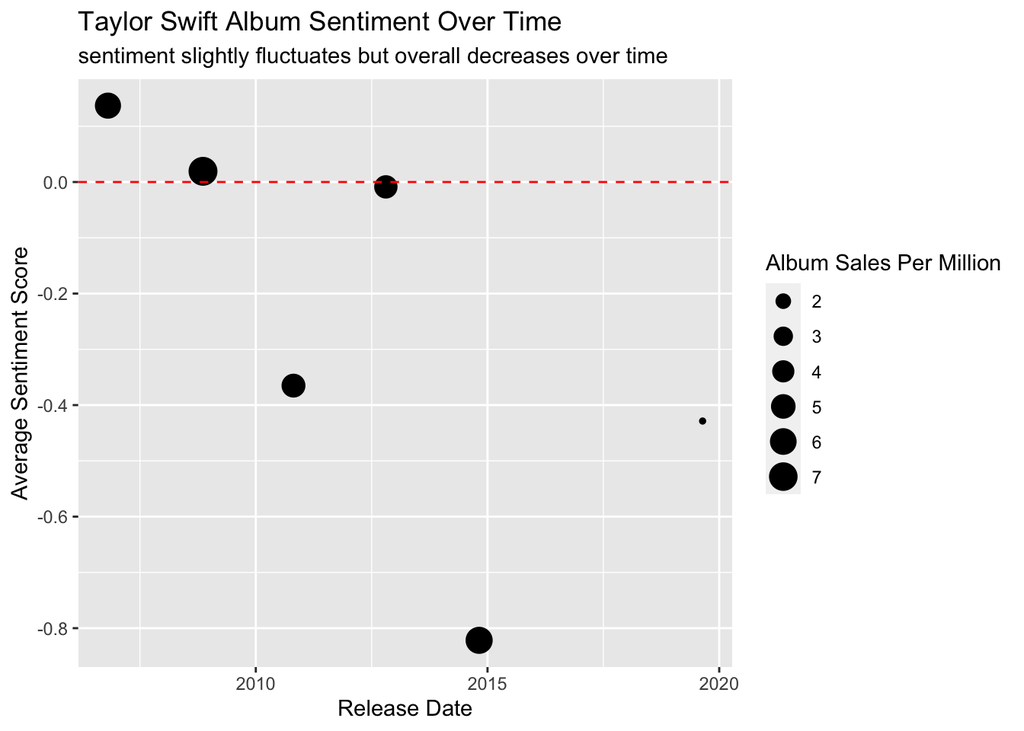

```r
sales <- sales %>% filter(country == "US") %>% rename(Album = title)#officially changing sales to only have US
joined_data<- inner_join(sales, ts_afinn_album, by = "Album")
joined_data<- unique(joined_data)
joined_data %>% group_by(Album) %>% ggplot(aes(x = released, y = avg_sent))+
  geom_point(aes(size = album_sales_permil))+
  geom_hline(yintercept = 0, linetype = "dashed", color = "red")+
  labs(x = "Release Date", y = "Average Sentiment Score", title = "Taylor Swift Album Sentiment Over Time", subtitle = "sentiment slightly fluctuates but overall decreases over time")+scale_size_continuous(name = "Album Sales Per Million")
```

Graph Interpretation: Earlier release date shows higher sentiment scores just above 0 compared to later release dates which are lower. This indicates that Taylor Swift used more positive language in her earlier albums, but overall her average language is either negative or close to average of negative and positive (0). You can also see that her album sales fluctuate, but the older albums with more positive language have a large dot, indicating that maybe her more positive music leads to more sales. This can explain why her sentiment fluctuates overtime as she may be changing her music sentiment based on sales.